# Администрирование локальных сетей

Лабораторная работа №6

Илья Колонтырский

Российский университет дружбы народов, Москва, Россия

16.03.2026

# Цель работы

## Цель лабораторной работы

Настроить межвлановую маршрутизацию в сети с использованием технологии **Router-on-a-Stick**.

Задачи работы:

- добавить маршрутизатор в существующую VLAN-инфраструктуру;
- настроить базовую конфигурацию маршрутизатора;
- реализовать маршрутизацию между VLAN;
- проверить сетевую связность между сегментами;
- изучить процесс передачи пакетов ICMP.

# Архитектура сети

## Топология сети

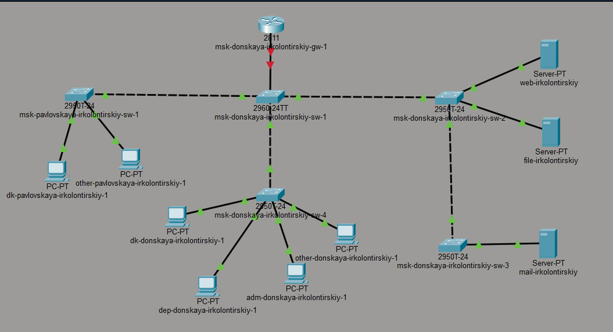

Топология сети

# Базовая настройка маршрутизатора

## Первоначальная конфигурация

На маршрутизаторе выполнены следующие действия:

- задано имя устройства;
- настроен пароль для консольного доступа;
- создан локальный пользователь администратора;
- включён защищённый удалённый доступ **SSH**;
- сгенерированы **RSA-ключи**.

Это обеспечивает безопасное удалённое администрирование сетевого оборудования.

## Настройка SSH

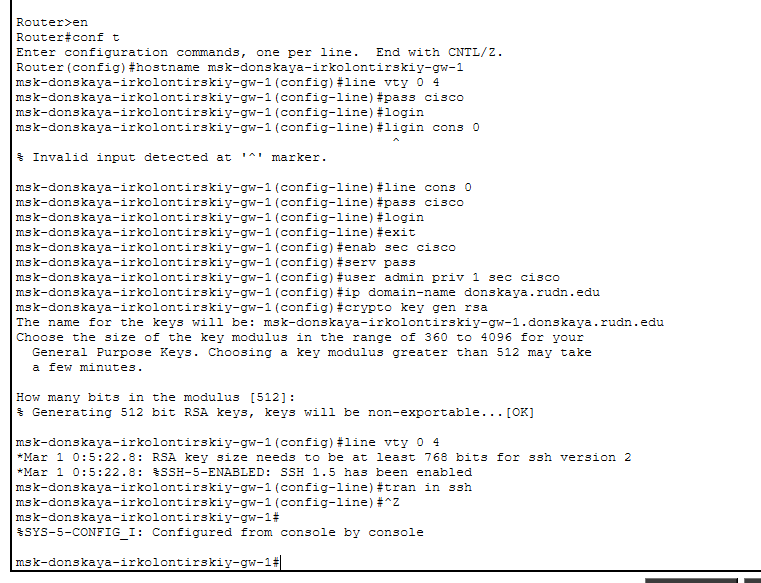

Конфигурация маршрутизатора

# Межвлановая маршрутизация

## Настройка VLAN-интерфейсов

Для реализации маршрутизации между VLAN на интерфейсе **FastEthernet0/0** были созданы подинтерфейсы.

Каждый подинтерфейс соответствует определённому VLAN и использует инкапсуляцию **IEEE 802.1Q**.

Шлюзы подсетей:

| VLAN | Подсеть | Шлюз |
| --- | --- | --- |
| 2 | 10.128.1.0/24 | 10.128.1.1 |
| 3 | 10.128.0.0/24 | 10.128.0.1 |
| 101 | 10.128.3.0/24 | 10.128.3.1 |
| 102 | 10.128.4.0/24 | 10.128.4.1 |
| 103 | 10.128.5.0/24 | 10.128.5.1 |
| 104 | 10.128.6.0/24 | 10.128.6.1 |

## Конфигурация подинтерфейсов

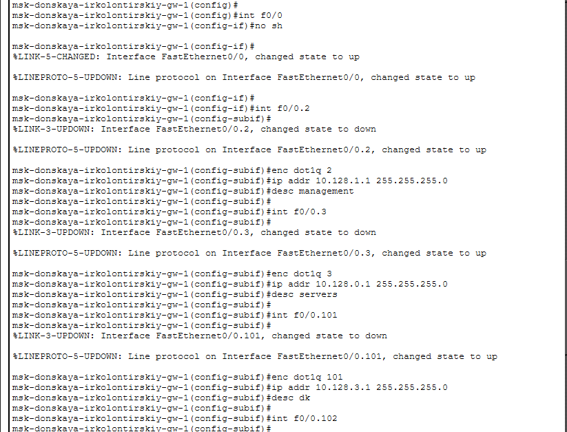

Настройка VLAN интерфейсов

# Проверка сетевой связности

## Проверка ping между VLAN

После настройки была выполнена проверка сетевой связности между устройствами из разных VLAN.

Результаты показывают успешную доставку ICMP-пакетов между сегментами сети.

Это подтверждает корректную работу межвлановой маршрутизации.

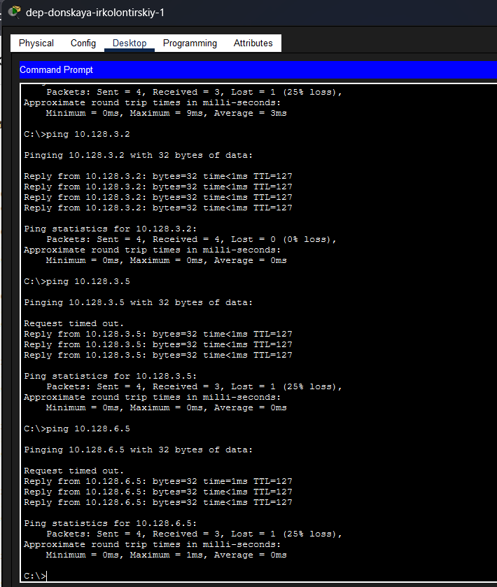

Проверка связности

## Дополнительная проверка

Дополнительно проверена связность с других рабочих станций.

Устройства из разных VLAN успешно обмениваются пакетами через маршрутизатор.

[figure not shown]

Дополнительная проверка

# Анализ передачи пакетов

## Режим симуляции Packet Tracer

Для анализа передачи данных использовался режим **Simulation**.

В этом режиме можно наблюдать:

- прохождение пакетов через устройства;
- обработку пакетов коммутаторами;
- маршрутизацию на уровне L3.

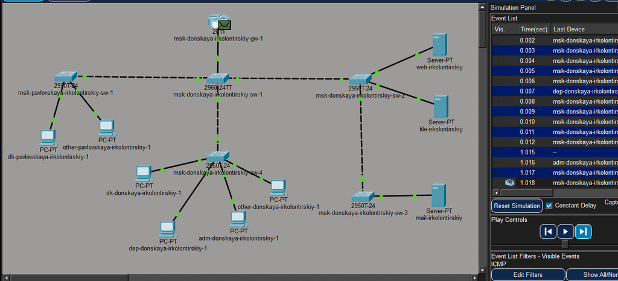

Режим симуляции

## Структура ICMP пакета

При анализе пакета были изучены заголовки:

- Ethernet (802.1Q VLAN tag)
- IP
- ICMP

В IP-заголовке можно наблюдать уменьшение **TTL** после прохождения маршрутизатора.

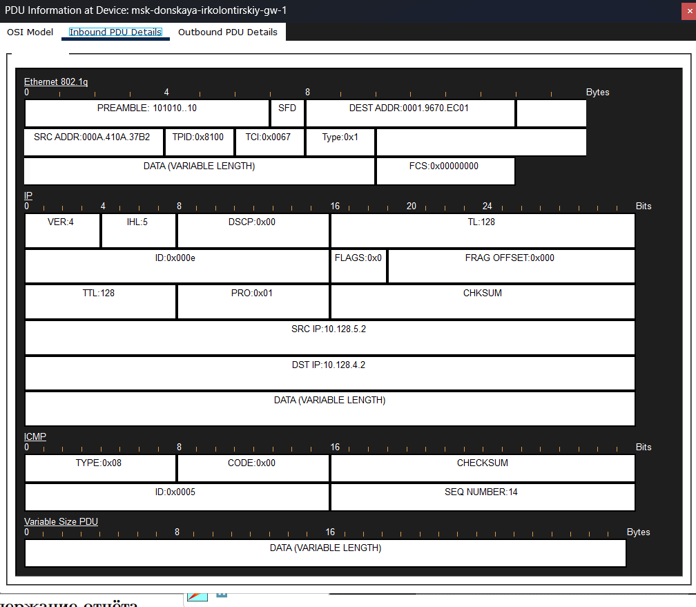

Входящий пакет

## Обработка пакета маршрутизатором

После обработки маршрутизатор формирует новый Ethernet-кадр:

- изменяются MAC-адреса источника и назначения;
- IP-адреса остаются прежними;
- TTL уменьшается на единицу.

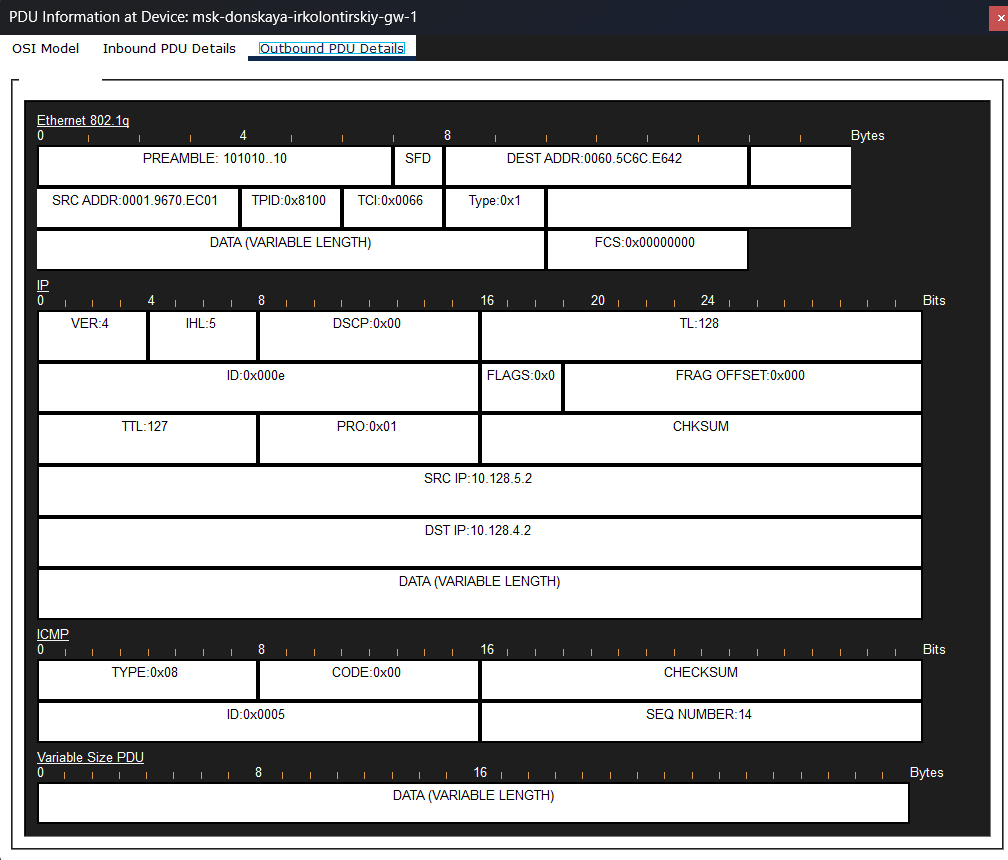

Исходящий пакет

# Вывод

## Результаты работы

В ходе лабораторной работы была реализована межвлановая маршрутизация в сети.

Были выполнены следующие действия:

- добавлен и настроен маршрутизатор Cisco 2811;
- реализована схема **Router-on-a-Stick**;
- настроены подинтерфейсы для VLAN;
- обеспечена маршрутизация между подсетями.

Проверка ping подтвердила корректную работу сети, а анализ в режиме Simulation позволил изучить процесс передачи ICMP-пакетов и структуру сетевых заголовков.